# Homework2

seongbin

2020 9 17

## 0.Data check

시계열 분석을 하기에 앞서 데이터의 분포를 살표본다.

```r
X<- read.csv("C://Users//stat//Desktop//학교//2-2//시계열//spot.csv")
head(X)
```

```
##   Spot
## 1  101
## 2   82
## 3   66
## 4   35
## 5   31
## 6    7
```

```r
T<-as.matrix(X)
dim(T)
```

```
## [1] 100   1
```

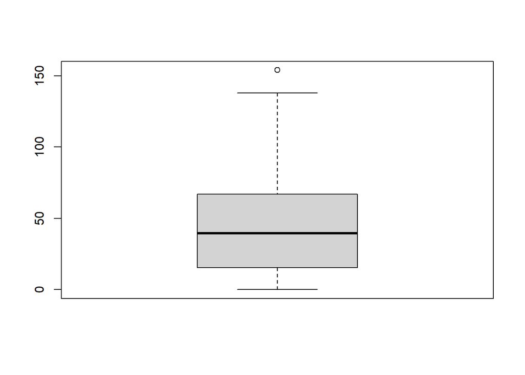

```r
boxplot(T[,1])
```

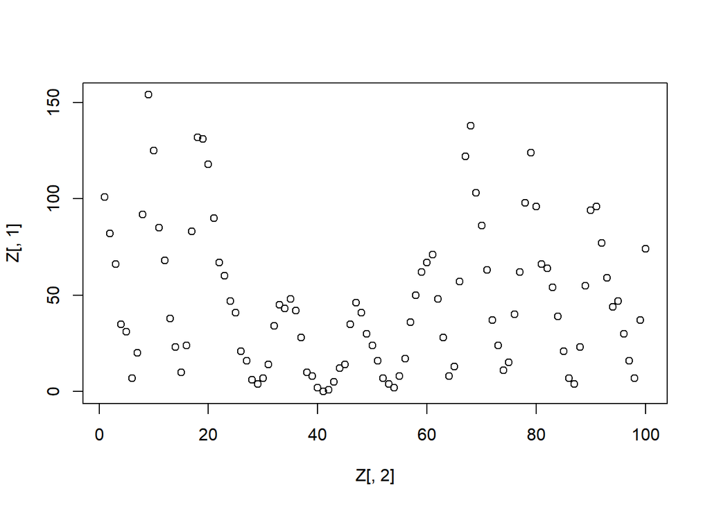

```r
Y=seq(1,100,1)
Z<-cbind(T,Y)
plot(Z[,2],Z[,1])
```

## SOL1

# Draw time series graph of sun spot

[figure not shown]

```r
T.ts=ts(data=T,frequency=1)
plot(T.ts, mai ="Time Series graph of Sun spot")
abline(h=mean(T.ts[,1]),col="blue")
```

# Do you see any cycle or seasonal effect?

```r
tseries::kpss.test(T.ts,null="Level")
```

```
##
##  KPSS Test for Level Stationarity
##
## data:  T.ts
## KPSS Level = 0.15966, Truncation lag parameter = 4, p-value = 0.1
```

```r
tseries::kpss.test(T.ts,null="Trend")
```

```
##
##  KPSS Test for Trend Stationarity
##
## data:  T.ts
## KPSS Trend = 0.15776, Truncation lag parameter = 4, p-value = 0.0402
```

## SOL2

# try 5-point moving average smoothing.

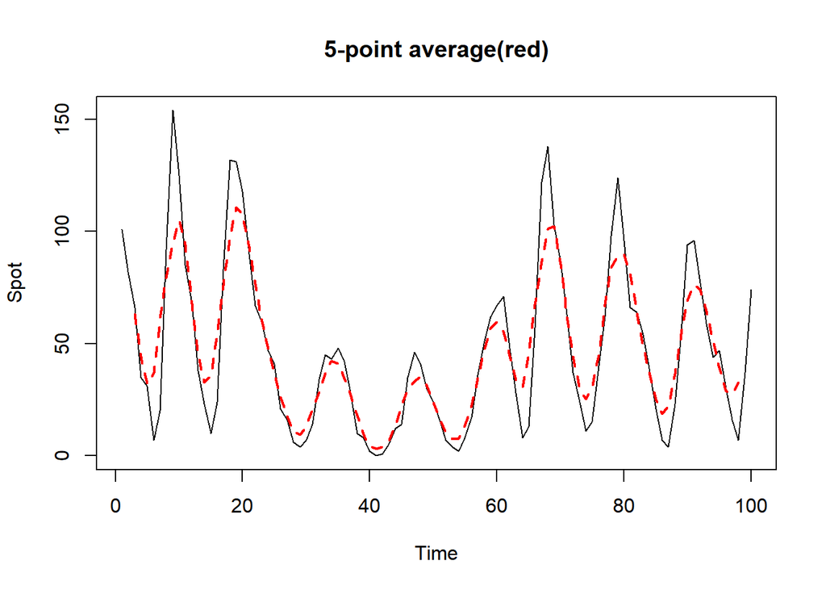

```r
m5=filter(T.ts, filter=rep(1/5,5))
plot(T.ts,main="5-point average(red)")
lines(m5,col="red",lty=2, lwd=2)
```

# Draw the plot of original graph in black, 4 point MA smoothing in red, mean value in blue.

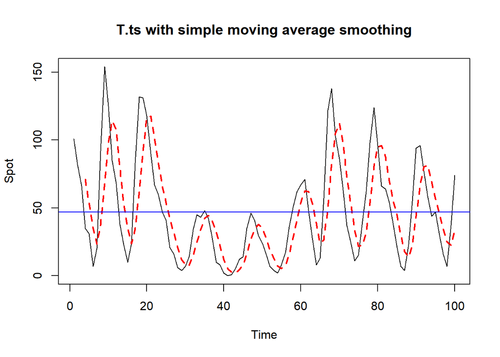

```r
ff=filter(T.ts, filter=rep(1,4)/4, method="convolution", sides=1)
plot(T.ts, main="T.ts with simple moving average smoothing")
lines(ff, col="red",lty=2, lwd=2)
abline(h=mean(T),col="blue")
```

## SOL3

## Check the residual plot

```r
head(ff,10)
```

```
##        [,1]
##  [1,]    NA
##  [2,]    NA
##  [3,]    NA
##  [4,] 71.00
##  [5,] 53.50
##  [6,] 34.75
##  [7,] 23.25
##  [8,] 37.50
##  [9,] 68.25
## [10,] 97.75
```

```r
#4개의 point로 MA를 시행하였으므로 앞의 3관측치를 제외
res=ff[-1:-3,]-T.ts[-1:-3,]
head(res,10)
```

```
##  [1]  36.00  22.50  27.75   3.25 -54.50 -85.75 -27.25  29.00  40.00  41.00
```

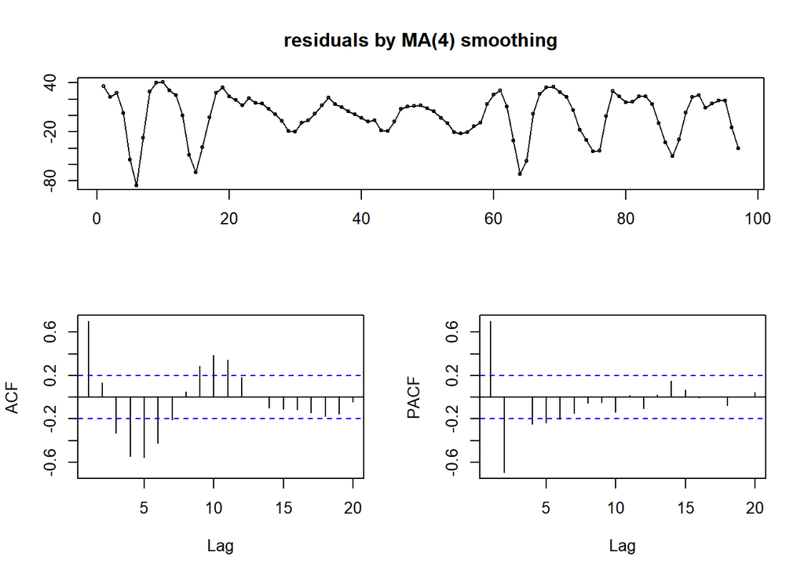

```r
library(forecast)
tsdisplay(res, main="residuals by MA(4) smoothing")
```

# check the stationary

ACF와 PACF를 보면 신뢰수준(표준편차 2배)을 벗어나는 값이 다수 존재하므로 정상성이 존재하지 않는다고 판단된다.

# the test the independence assumption

```r
Box.test(res)
```

```
##
##  Box-Pierce test
##
## data:  res
## X-squared = 47.341, df = 1, p-value = 5.964e-12
```

```r
alpha=0.1 #exponential
 ho=HoltWinters(T.ts, alpha=0.1, beta=F, gamma=F)#exponential smoothing#(beta=F, gamma=F): no trend and no seasonal effect
 ho
```

```
## Holt-Winters exponential smoothing without trend and without seasonal component.
##
## Call:
## HoltWinters(x = T.ts, alpha = 0.1, beta = F, gamma = F)
##
## Smoothing parameters:
##  alpha: 0.1
##  beta : FALSE
##  gamma: FALSE
##
## Coefficients:
##       [,1]
## a 46.92938
```

```r
 head(ho$fitted) #fitting value
```

```
## Time Series:
## Start = 2
## End = 7
## Frequency = 1
##        xhat     level
## 2 101.00000 101.00000
## 3  99.10000  99.10000
## 4  95.79000  95.79000
## 5  89.71100  89.71100
## 6  83.83990  83.83990
## 7  76.15591  76.15591
```

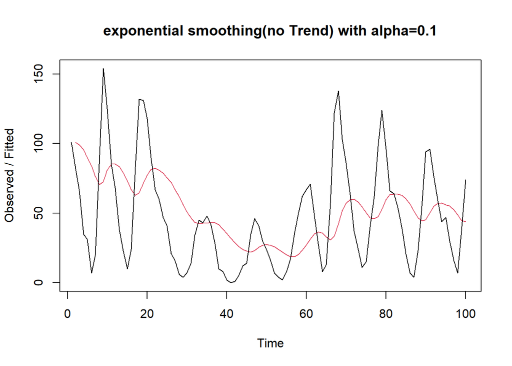

```r
 plot(ho,main = "exponential smoothing(no Trend) with alpha=0.1")
```

```r
 ha=HoltWinters(T.ts,beta=F,gamma=F) #exponential smoothing
 ha
```

```
## Holt-Winters exponential smoothing without trend and without seasonal component.
##
## Call:
## HoltWinters(x = T.ts, beta = F, gamma = F)
##
## Smoothing parameters:
##  alpha: 0.9999339
##  beta : FALSE
##  gamma: FALSE
##
## Coefficients:
##       [,1]
## a 73.99755
```

```r
 head(ha$fitted) #fitting value
```

```
## Time Series:
## Start = 2
## End = 7
## Frequency = 1
##         xhat      level
## 2 101.000000 101.000000
## 3  82.001256  82.001256
## 4  66.001058  66.001058
## 5  35.002049  35.002049
## 6  31.000265  31.000265
## 7   7.001587   7.001587
```

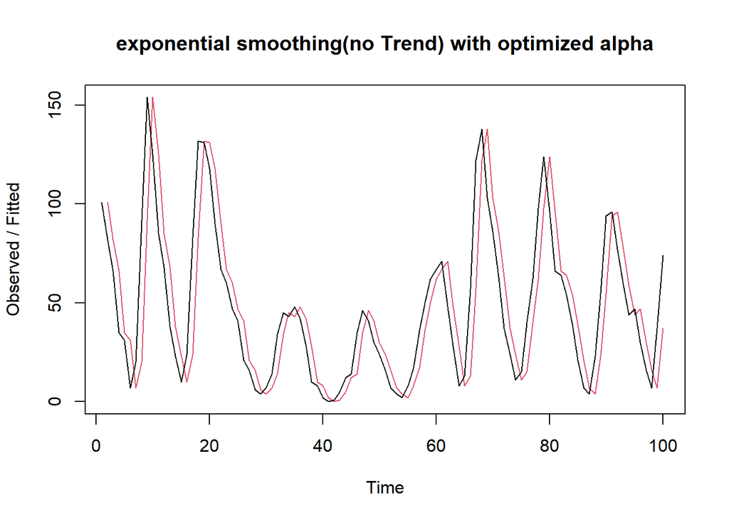

```r
 plot(ha,main="exponential smoothing(no Trend) with optimized alpha") #the red line is the fitted value
```

# If you think we need a trend, or seasonal, or both try them

또한, 계절성을 고려한 지수 평활법을 사용하기 위해서 frequency값을 4로 임의로 설정하고 진행한다.

```r
T.ts=ts(data=T,frequency=4)
Ta=HoltWinters(T.ts,gamma=F) #exponential smoothing(trend)
Ta
```

```
## Holt-Winters exponential smoothing with trend and without seasonal component.
##
## Call:
## HoltWinters(x = T.ts, gamma = F)
##
## Smoothing parameters:
##  alpha: 1
##  beta : 0.0678801
##  gamma: FALSE
##
## Coefficients:
##        [,1]
## a 74.000000
## b  1.870588
```

```r
head(Ta$fitted)
```

```
##            xhat level     trend
## 1 Q3  63.000000    82 -19.00000
## 1 Q4  47.203640    66 -18.79636
## 2 Q1  15.375256    35 -19.62474
## 2 Q2  12.435865    31 -18.56413
## 2 Q3 -11.933122     7 -18.93312
## 2 Q4   3.234502    20 -16.76550
```

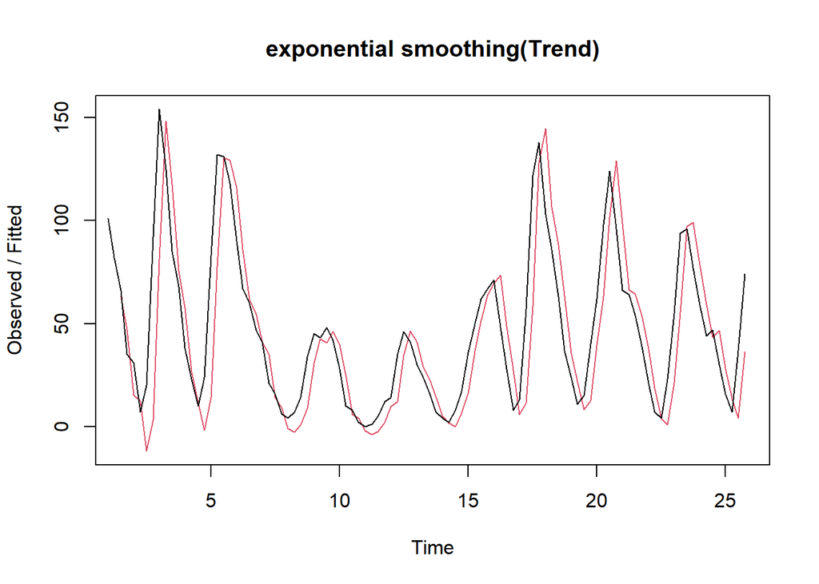

```r
plot(Ta,main="exponential smoothing(Trend)")
```

```r
S.ts=ts(data=T,frequency=4)
Sa=HoltWinters(S.ts,beta=F) #exponential smoothing(Seasonal)
Sa
```

```
## Holt-Winters exponential smoothing without trend and with additive seasonal component.
##
## Call:
## HoltWinters(x = S.ts, beta = F)
##
## Smoothing parameters:
##  alpha: 0.9350651
##  beta : FALSE
##  gamma: 1
##
## Coefficients:
##          [,1]
## a  74.3403045
## s1 -1.5697735
## s2 -0.3844468
## s3  2.6566979
## s4 -0.3403045
```

```r
head(Sa$fitted)
```

```
##            xhat     level     season
## 2 Q1  77.812500  69.12500   8.687500
## 2 Q2   8.664767  25.35227 -16.687500
## 2 Q3  34.233102  23.79560  10.437500
## 2 Q4   8.049226  10.48673  -2.437500
## 3 Q1  94.633894  88.98616   5.647733
## 3 Q2 127.701731 144.49733 -16.795602
```

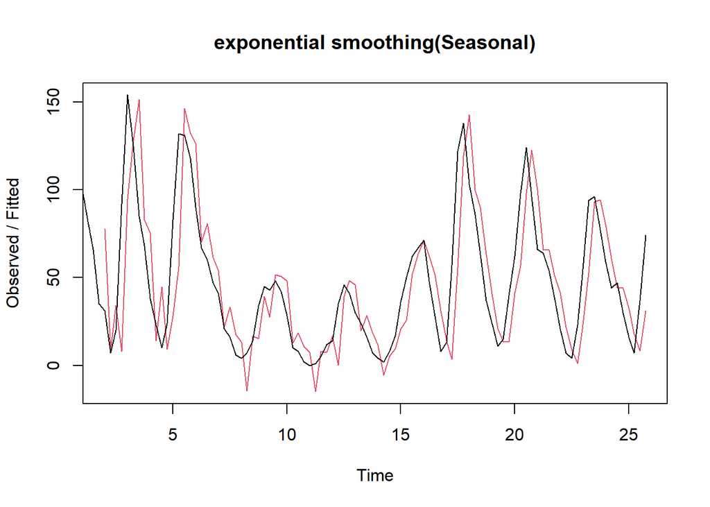

```r
plot(Sa,main="exponential smoothing(Seasonal)")
```

```r
S.ts=ts(data=T,frequency=4)
TSa=HoltWinters(S.ts) #exponential smoothing(Trend&Seasonal)
TSa
```

```
## Holt-Winters exponential smoothing with trend and additive seasonal component.
##
## Call:
## HoltWinters(x = S.ts)
##
## Smoothing parameters:
##  alpha: 0.9370146
##  beta : 0.03377394
##  gamma: 1
##
## Coefficients:
##          [,1]
## a  68.8328871
## b   0.4755106
## s1  4.2076887
## s2  5.3628840
## s3  8.2509240
## s4  5.1671129
```

```r
head(TSa$fitted)
```

```
##            xhat      level      trend     season
## 2 Q1  66.737500  69.125000 -11.075000   8.687500
## 2 Q2  -4.330034  24.563439 -12.205973 -16.687500
## 2 Q3  21.563959  22.973874 -11.847415  10.437500
## 2 Q4  -4.673403   9.661006 -11.896909  -2.437500
## 3 Q1  85.947534  88.348491  -8.837517   6.436561
## 3 Q2 120.619373 143.277130  -6.683883 -15.973874
```

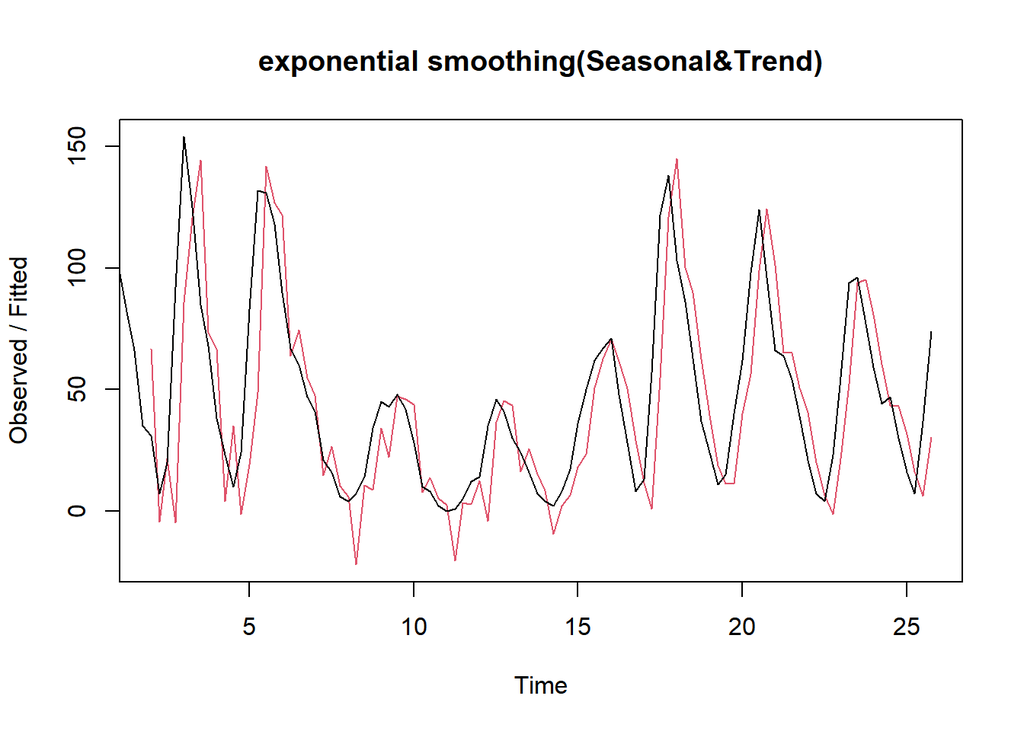

```r
plot(TSa,main="exponential smoothing(Seasonal&Trend)")
```

## Please address all the moeling and show how you find the best exponential smoothing model for spot data.

RMSE를 비교하여 최적의 지수 평활법 모델을 선정한다.

```r
library(tseries)
library(forecast)
fTa=forecast(Ta)
names(fTa)
```

```
##  [1] "method"    "model"     "level"     "mean"      "lower"     "upper"
##  [7] "x"         "series"    "fitted"    "residuals"
```

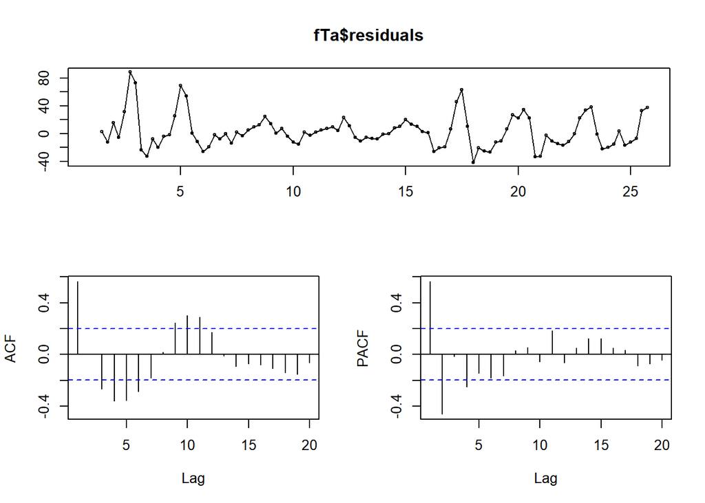

```r
tsdisplay(fTa$residuals)
```

```r
Box.test(fTa$residuals,type="Box-Pierce")
```

```
##
##  Box-Pierce test
##
## data:  fTa$residuals
## X-squared = 30.996, df = 1, p-value = 2.585e-08
```

```r
tseries::kpss.test(fTa$residuals,null="Level")
```

```
##
##  KPSS Test for Level Stationarity
##
## data:  fTa$residuals
## KPSS Level = 0.12067, Truncation lag parameter = 4, p-value = 0.1
```

```r
accuracy(fTa)
```

```
##                    ME     RMSE      MAE MPE MAPE      MASE      ACF1
## Training set 3.137373 23.61944 16.89736 Inf  Inf 0.3529475 0.5623951
```

```r
fha=forecast(ha)
names(fha)
```

```
##  [1] "method"    "model"     "level"     "mean"      "lower"     "upper"
##  [7] "x"         "series"    "fitted"    "residuals"
```

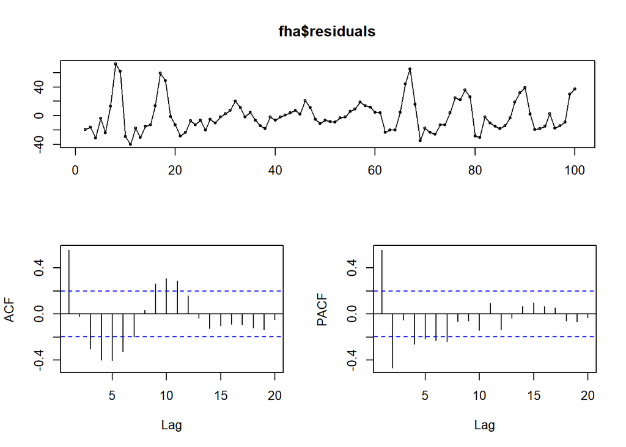

```r
tsdisplay(fha$residuals)
```

```r
Box.test(fha$residuals,type="Box-Pierce")
```

```
##
##  Box-Pierce test
##
## data:  fha$residuals
## X-squared = 30.077, df = 1, p-value = 4.153e-08
```

```r
tseries::kpss.test(fha$residuals,null="Level")
```

```
##
##  KPSS Test for Level Stationarity
##
## data:  fha$residuals
## KPSS Level = 0.042049, Truncation lag parameter = 4, p-value = 0.1
```

```r
accuracy(fha)
```

```
##                    ME     RMSE      MAE  MPE MAPE     MASE      ACF1
## Training set -0.27277 22.45279 17.14213 -Inf  Inf 1.000042 0.5511841
```

```r
fSa=forecast(Sa)
names(fSa)
```

```
##  [1] "method"    "model"     "level"     "mean"      "lower"     "upper"
##  [7] "x"         "series"    "fitted"    "residuals"
```

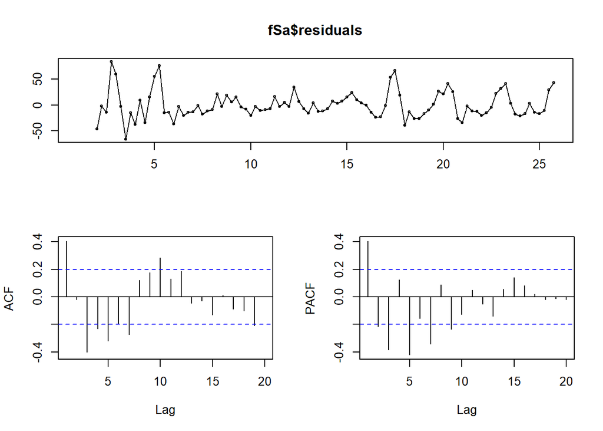

```r
tsdisplay(fSa$residuals)
```

```r
Box.test(fSa$residuals,type="Box-Pierce")
```

```
##
##  Box-Pierce test
##
## data:  fSa$residuals
## X-squared = 15.538, df = 1, p-value = 8.085e-05
```

```r
tseries::kpss.test(fSa$residuals,null="Level")
```

```
##
##  KPSS Test for Level Stationarity
##
## data:  fSa$residuals
## KPSS Level = 0.02891, Truncation lag parameter = 4, p-value = 0.1
```

```r
accuracy(fSa)
```

```
##                      ME     RMSE      MAE  MPE MAPE      MASE     ACF1
## Training set 0.05809873 25.79089 19.20619 -Inf  Inf 0.4011737 0.402316
```

```r
fTSa=forecast(TSa)
names(fTSa)
```

```
##  [1] "method"    "model"     "level"     "mean"      "lower"     "upper"
##  [7] "x"         "series"    "fitted"    "residuals"
```

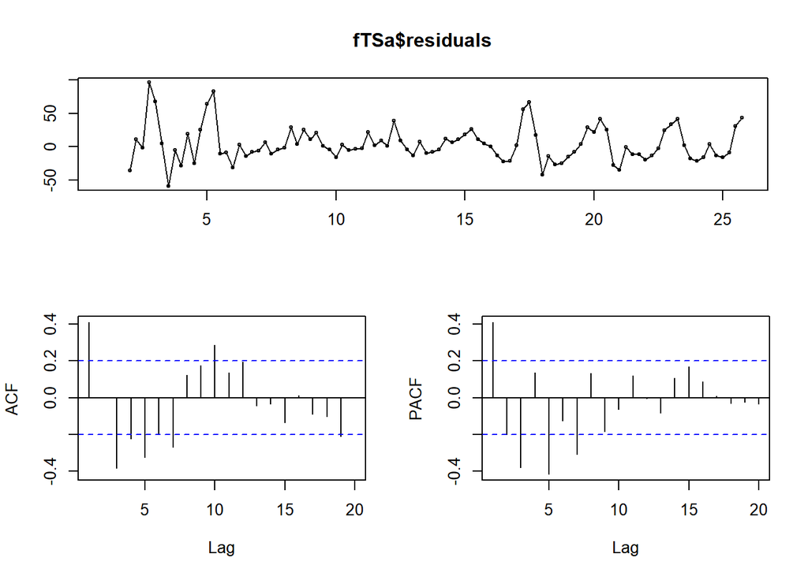

```r
tsdisplay(fTSa$residuals)
```

```r
Box.test(fTSa$residuals,type="Box-Pierce")
```

```
##
##  Box-Pierce test
##
## data:  fTSa$residuals
## X-squared = 16.099, df = 1, p-value = 6.01e-05
```

```r
tseries::kpss.test(fTSa$residuals,null="Level")
```

```
##
##  KPSS Test for Level Stationarity
##
## data:  fTSa$residuals
## KPSS Level = 0.060202, Truncation lag parameter = 4, p-value = 0.1
```

```r
accuracy(fTSa)
```

```
##                   ME     RMSE      MAE  MPE MAPE      MASE      ACF1
## Training set 3.80191 26.57515 19.03591 -Inf  Inf 0.3976169 0.4095143
```

## From your best model, find the forecast of next 4 points.

MA(이동평균법)의 경우 예측의 목적 보다는, 분해법에서 ’계절조정’에 주로 사용된다. 그러므로 지수 평활법 중 최적 모델인 “Exponential smoothing(no Trend) with optimized alpha”로 예측을 실시한다.

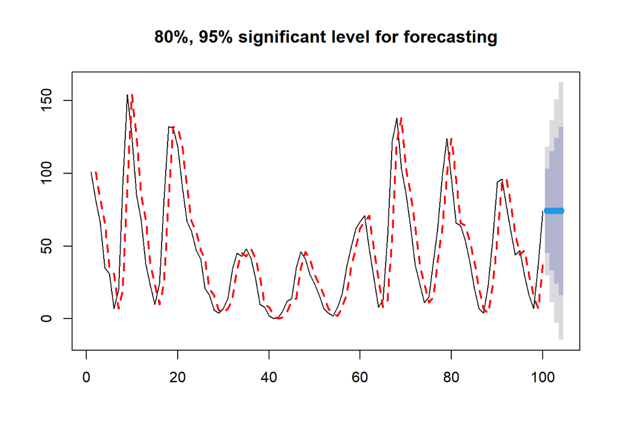

```r
F=forecast(ha, h=4)
plot(F,main="80%, 95% significant level for forecasting")
lines(F$fitted, col="red", lty=2, lwd=2)
```

```r
FF=forecast(ha, h=4,fan=T)
```

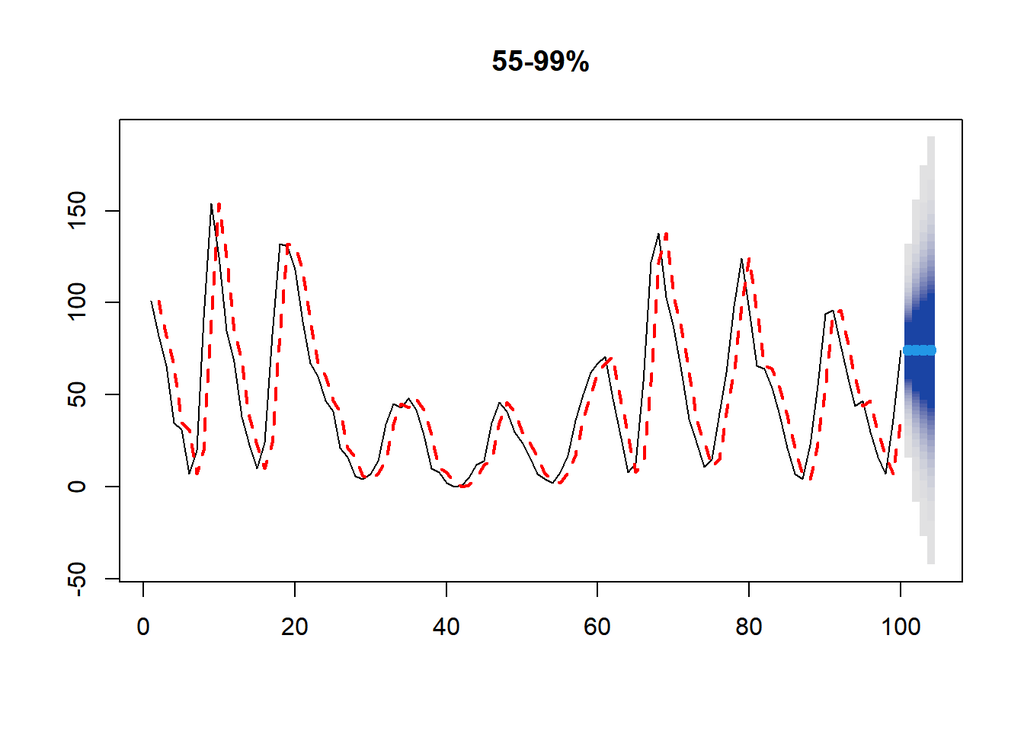

```r
plot(FF,main="55-99%")
lines(FF$fitted,col="red", lty=2, lwd=2)
```